# Using supervised machine learning to determine the importance of mini-mental state examination score and normalized whole-brain volume when predicting dementia group

Y3865992

02/12/2020

# Introduction

Dementia is a broad category for age-related diseases caused by a loss of 20% of brain function. Dementia is characterised by cognitive impairment, which represents a decline from previous level of functioning, and is associated with impairment in functional abilities (National Collaborating Centre for Mental Health (UK) 2007). It is estimated that 850,00 people in the UK, and 54 million people globally are living with dementia (Prince et al. 2015). One million people in the UK are projected to have dementia by 2015 and this is though to increase to 2 million by 2050 (Prince et al. 2014). The increasing prevalence of Dementia has made the diagnosis of patients critical. To aid in diagnosis researchers are keen to predict dementia group from data collected from subject visits. The Mini-Mental state Examination (MMSE) is a 30 point questionnaire that is used to assess mental status (Kurlowicz and Wallace 1999). Scores greater or equal to 24 indicate normal cognition. Scores less than 24 indicate cognitive impairment and correlate with dementia: mild (19-23), moderate (10-18) or severe (≤ 9 points). Normalized whole-brain volume (nWBV) is the proportion of voxels that are labeled as gray or white matter in the atlas-masked image expressed as a percentage. The aim of this project is to determine the importance of MMSE and nWBV in predicting dementia group by producing reproducible models with and without MMSE and nWBV.

# Methods

## Data description

There are two data sets in separate sheets contained in the same file: dementia.xlsx

The subjects were right-handed men and women aged 60 to 96. Each subject was scanned on two or more visits, separated by at least one year for a total of 373 imagine sessions. In a single scan session three or four individual T1-weighted MRI scans were obtained per subject. Subjects were characterised as nondemented, demented or converted (nondemented on their initial visit but characterised as demented at a later visit). Each subject was allocated a subject id, this subject id is the same for each subject in both data sheets.

The data in the visit data sheet are the data taken from subject visits and data obtained from MRI scans. Each row contains the data collected at a single visit, ordered by subject id and arranged in columns. The data collected and column titles are:

- subject id
- mri number
- Visit: Number of visit
- Age
- MMSE: Mini-Mental state Examination
- CDR: Clinical Dementia Rating
- eTIV: Estimated total intracranial volume
- nWBV: Normalized whole-brain volume
- ASF: Atlas scaling factor

The data in the patient data sheet are general data about the subject and their dementia group. Each row contains the data about a single subject ordered by subject id and arranged in columns. The data collected and column titles are:

- Subject ID
- Group
- M/F - Gender
- EDUC - Years of education
- SES - Socioeconomic status

## Data preparation

`tidyverse` with the `readxl` package was used to import the data from the excel file (Wickham and Bryan 2019). To process the raw data `tidyverse` packages were used (Wickham 2019). The two data sheets were imported into separate data frames before being merged into one data frame that is ordered first by subject id then MRI number. Rows of the data set with missing data were filtered out.

## Linear Discriminant Analysis models

To determine the importance of MMSE and nWBV when predicting dementia group of patients, two Linear Discriminant Analysis (LDA) models were used. The LDA models were carried out using the package `caret` (Kuhn 2020). LDA is a supervised method of machine learning. LDA is a method used to find a linear combination of features that separates two or more classes of objects. LDA attempts to model the difference between the classes of data, in this case the dementia groups: Demented, Nondemented and Converted. The first LDA model produced includes the factors age, education, social economic status and gender. The second LDA model includes the same factors included in the first model along with MMSE and nWBV. The two models’ accuracy will be compared to determine the importance of MMSE and nWBV in predicting dementia group.

Overall statistics for the test data of both LDA models were extracted into separate data frames. These data frames were merged into a single data frame. To allow for plots to be produced from this data the data frame was transposed.

# Results

All figures were produced using `ggplot` from the `ggplot2` package and saved in a file named Figures using `ggsave` (Wickham et al. 2020). The `rmarkdown` (Allaire et al. 2019) and bookdown (Xie 2016) packages were used to produce figure legends.

Scatter plots showing the separation between each group of the first two linear discriminates for model 1 and model 2 were plotted using `ggplot` from the `ggplot2` package (Wickham et al. 2020) (see figure 1).

A bar chart comparing the accuracy of the two LDA models was plotted using data from the `overall_data` frame. The accuracy for model 1 is 0.586 and the accuracy of model 2 is 0.667. The difference between the accuracy of the two models is not significant as the error bars overlap (see figure 2).

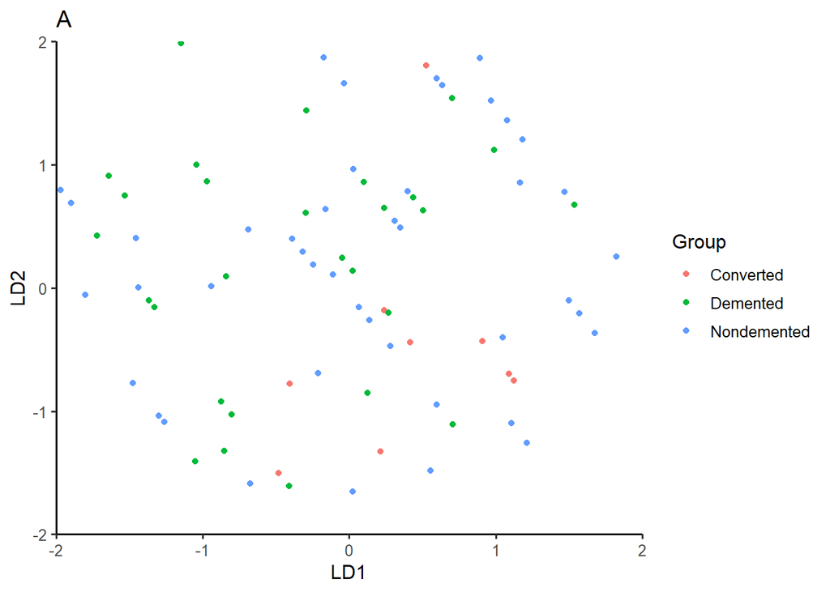

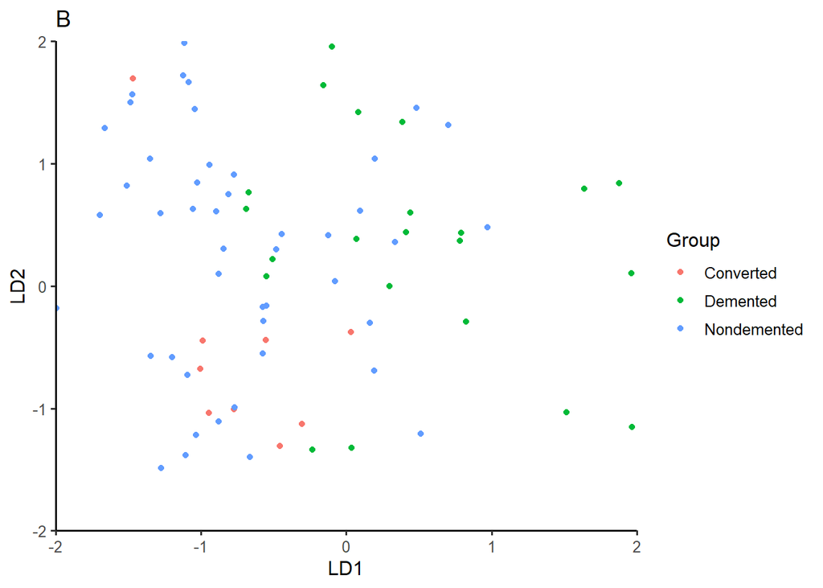

Figure 1: A. Linear discriminant analysis model with the factors age, education, ses and gender. The accuracy of model 1 is 0.586 (3sf). B. Linear discriminant analysis model with the factors age, education, ses, gender, MMSE and nWBV. The accuracy of model 2 is 0.667 (3sf).

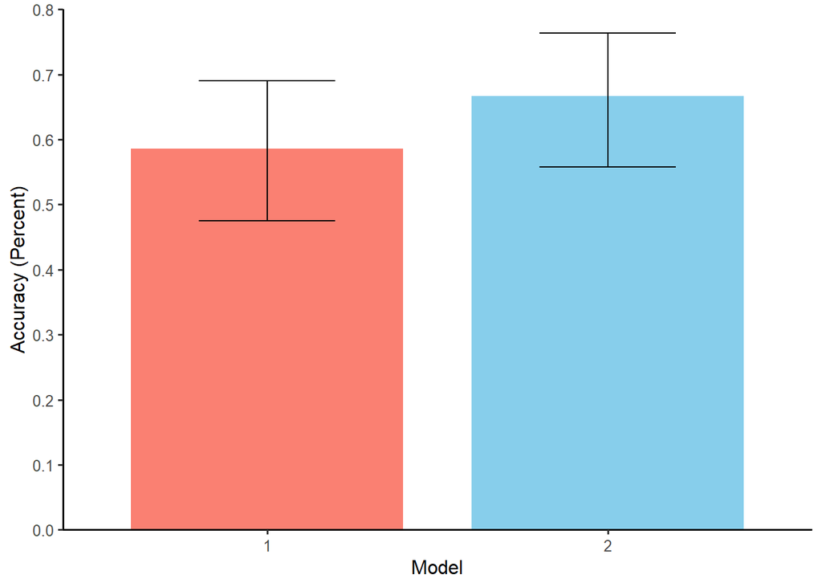

Figure 2: Bar chart showing the accuracy of model 1 and model 2. Error bars are 95% confidence intervals. The accuracy of model 1 is 0.586 (3sf) and the 95% confidence interval is 0.476 (3sf) - 0.691 (3sf). The accuracy of model 2 is 0.667 (3sf) and the 95% confidence interval is 0.557 (3sf) - 0.764 (3sf).

# Conclusions

A reproducible protocol for determining the importance of MMSE and nWBV in predicting dementia group has been produced. Upon visualizing the accuracy of the LDA models in a bar chart it is easy to differentiate the accuracy of the two models with and without MMSE and nWBV. The data shows that there is no significant difference in the accuracy of the LDA model when MMSE and nWBV are included into the model.

These findings can be further developed by using LDA models to determine which combination of factors obtained during subject visits are the most successful for predicting dementia group. This method of modeling to predict the dementia group can also be used to predict Clinical Dementia Rating which is a value used to diagnose dementia patients.

## Word Count

Word count calculated with word_count_addin supplied by Emma Rand. Session information has also been added to the word count as it is written into a distinct file.

This document: 839  
README: 87  
Session info: 181  
**Total: 1107**

# Bibliography

Allaire, JJ, Yihui Xie, Jonathan McPherson, Javier Luraschi, Kevin Ushey, Aron Atkins, Hadley Wickham, Joe Cheng, Winston Chang, and Richard Iannone. 2019. *Rmarkdown: Dynamic Documents for r*. https://github.com/rstudio/rmarkdown.

Kuhn, Max. 2020. *Caret: Classification and Regression Training*. https://CRAN.R-project.org/package=caret.

Kurlowicz, L, and M Wallace. 1999. “The Mini-Mental State Examination (MMSE).” *J. Gerontol. Nurs.* 25 (5): 8–9.

National Collaborating Centre for Mental Health (UK). 2007. *DEMENTIA*. British Psychological Society.

Prince, Martin, Martin Knapp, Maelenn Guerchet, Paul McCrone, Matthew Prina, A Comas-Herrera, Raphael Wittenberg, et al. 2014. “Dementia UK: Second Edition - Overview,” September.

Prince, Martin, Anders Wimo, Maelenn Guerchet, Gemma-Claire Ali, and Matthew Prina. 2015. “World Alzheimer Report 2015. The Global Impact of Dementia. An Analysis of Prevalence, Incidence, Cost and Trends,” August.

Wickham, Hadley. 2019. *Tidyverse: Easily Install and Load the Tidyverse*. https://CRAN.R-project.org/package=tidyverse.

Wickham, Hadley, and Jennifer Bryan. 2019. *Readxl: Read Excel Files*. https://CRAN.R-project.org/package=readxl.

Wickham, Hadley, Winston Chang, Lionel Henry, Thomas Lin Pedersen, Kohske Takahashi, Claus Wilke, Kara Woo, Hiroaki Yutani, and Dewey Dunnington. 2020. *Ggplot2: Create Elegant Data Visualisations Using the Grammar of Graphics*. https://CRAN.R-project.org/package=ggplot2.

Xie, Yihui. 2016. *Bookdown: Authoring Books and Technical Documents with R Markdown*. Boca Raton, Florida: Chapman; Hall/CRC. https://github.com/rstudio/bookdown.